# Lab6_R4L

## Baiyu Chen

In this lab I try to figure out the relationship between flight time and delay in Denver Airport. First I filter the data, I keep the data which planeâs departure and arrive is Denver airport. Then I set if a flight delay more than 15 minutes is a long delay, less than 0 minute is early arrive, otherwise is not delay. In fact I found the probability of delay is similarity between a long flight plane and a short flight plane, but more delay if a plane’s flight time more than 450 minutes. Also I found there are more delay during winter and less delay during summer.

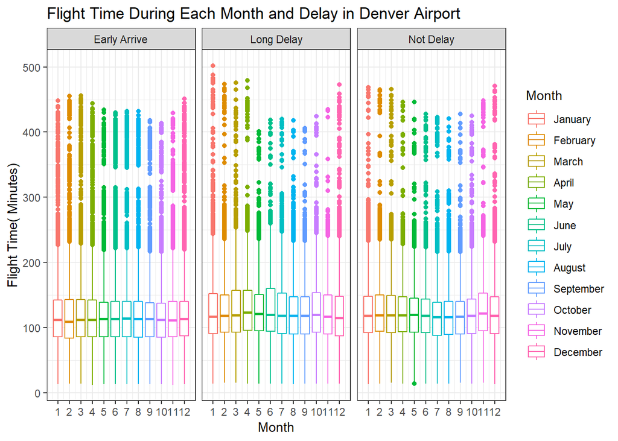

```r
COflights_NAdrop<-COflights %>%
  drop_na(ARR_DELAY)


COflights_longflight<-COflights_NAdrop %>%
  mutate(LONG_FIGHT=ifelse(AIR_TIME >= 300, 1, ifelse(AIR_TIME < 120, 0, ifelse(AIR_TIME>=120&AIR_TIME<300,2, AIR_TIME))))

coflights_DEN2<-filter(COflights_longflight, ORIGIN =="DEN"|DEST=="DEN")


coflughts_delay<-COflights_NAdrop %>%
    mutate(DELAY=ifelse(ARR_DELAY >= 15, 1, ifelse(ARR_DELAY <0, 0, ifelse(ARR_DELAY>=0 &ARR_DELAY < 15, 2, ARR_DELAY))))


coflights_DEN<-filter(coflughts_delay, ORIGIN =="DEN"|DEST=="DEN")

ggplot(data = coflights_DEN, mapping=aes(y = AIR_TIME,x=MONTH, color=as.factor(MONTH)))+
  geom_boxplot(mapping = aes(group = cut_width(MONTH, 1)))+
  facet_wrap(~DELAY, labeller=labeller(DELAY = c('0' = 'Early Arrive', '1' = 'Long Delay','2' = 'Not Delay')))+
  scale_x_continuous(breaks=c(0,1,2,3,4,5,6,7,8,9,10,11,12),labels = c('0','1','2','3','4','5','6','7','8','9','10','11','12'))+
  theme_bw()+
  ylab("Flight Time( Minutes)")+
  xlab("Month")+
  ggtitle("Flight Time During Each Month and Delay in Denver Airport")+
  scale_color_discrete(name = 'Month', labels = c( 'January', 'February', 'March', 'April', 'May', 'June','July', 'August','September','October','November','December'))
```

```r
# The probability of a long fight(more than 5 hours) in all not cancel fights
p1 <- filter(coflights_DEN2,LONG_FIGHT ==1)%>% count()/count(COflights_NAdrop)
p1
```

```
##             n
## 1 0.004093333
```

```r
#The probability of a long fight delay(arrive delay more than 15 minute) in all not cancel fights
p2 <-filter(coflights_DEN2,LONG_FIGHT ==1, ARR_DELAY >= 15)%>% count()/count(COflights_NAdrop)
p2
```

```
##              n
## 1 0.0006271359
```

```r
#The probability of a fight delay give that it's a long fight.
p3<-p2/p1
p3
```

```
##           n
## 1 0.1532091
```

```r
# The probability of a short fight(less than 2 hours) in all not cancel fights
p1s <-filter(coflights_DEN2,LONG_FIGHT ==0)%>% count()/count(COflights_NAdrop)
p1s
```

```
##           n
## 1 0.5290485
```

```r
#The probability of a short fight delay(arrive delay more than 15 minute) in all not cancel fights
p2s<-filter(coflights_DEN2,LONG_FIGHT ==0, ARR_DELAY >= 15)%>% count()/count(COflights_NAdrop)
p2s
```

```
##            n
## 1 0.08220777
```

```r
#The probability of a fight delay give that it's a short fight.

p3s<-p2s/p1s
p3s
```

```
##          n
## 1 0.155388
```

## Who did what?

Jason Giblin:I completed my individual part of determining the top 3 carriers and what their conditional probabilities were for arrival delays. Along with Yen-Ting, I wrote both of our teamâs overall questions, conclusions, recommendation, and the coding for the team part. I also used my expertise of probability to help others with the probability questions.

Yen-Ting Shen: I complete my individual part. In addition, I worked with Jason Giblin to finish the team plots and over all questions.

Tiger Su: Beside my individual part, I helped Emery fix some of the rstudio problems. This week I did not get involved much into the team plot. Next week, I will try my best help my teammates with the team plot.

Emery Schattinger: Besides my individual part,helped Tiger fix problems with formatting and gave pretty good ideas, but didn’t gelp that much with the team plots this week as much as I should have.

Baiyu Chen: Otherthan my individual part, I helped the group to conclude some of the team conclusion 2.